# Caso Programa de MBA

Data Analysis in R & Data Visualization

Elaborado por *Dyjannette Alva Quiroz

### **1. Introducción**

El presente caso se analiza desde la perspectiva de Marie Daer, quien se encuentra interesada en llevar un programa de MBA. Ella espera responder algunas preguntas importantes para ayudar a decidir si se matricula en dicho programa, en base a una encuesta realizada a los estudiantes del programa tres meses luego de su graduación.

En particular, está interesada en conocer respecto al salario inicial de los estudiantes graduados, si el género o edad tienen relación con el salario, y si los estudiantes están satisfechos con el programa. Asimismo, desea conocer si su puntaje en el GMAT tiene alguna relación con el puntaje logrado en el curso, dado que su resultado GMAT fue relativamente bajo al no ser el inglés su lengua materna.

### **2. Objetivo del caso**

1. ¿Cuál es el objetivo de aspirantes a postulantes como Marie Daer?
- Objetivo general: Decidir sobre la inscripción al programa de MBA en esta escuela en particular.
- Objetivos específicos
  - Conocer el nivel de salario que los estudiantes esperarian ganar al graduarse.
  - Determinar si existen algunas otras variables que influyen en el nivel de salario que esperarian recibir.
  - Determinar si el programa es bien calificado por los graduados.

### **3. Análisis**

```r
Base1 <- read.xlsx("W12513-XLS-ENG.xlsx", sheetName = "Base1")
attach(Base1)
glimpse(Base1)
```

```
## Rows: 274
## Columns: 9
## $ ID       <dbl> 1, 2, 3, 4, 5, 6, 7, 8, 9, 10, 11, 12, 13, 14, 15, 16, 17, 18~
## $ age      <dbl> 23, 24, 24, 24, 24, 24, 25, 25, 25, 25, 26, 26, 26, 26, 26, 2~
## $ sex      <dbl> 2, 1, 1, 1, 2, 1, 1, 2, 1, 1, 1, 2, 1, 1, 2, 2, 2, 1, 1, 1, 2~
## $ gmat_tot <dbl> 620, 610, 670, 570, 710, 640, 610, 650, 630, 680, 740, 610, 7~
## $ gmat_qpc <dbl> 77, 90, 99, 56, 93, 82, 89, 88, 79, 99, 99, 75, 95, 97, 84, 6~
## $ gmat_vpc <dbl> 87, 71, 78, 81, 98, 89, 74, 89, 91, 81, 98, 87, 95, 97, 93, 9~
## $ gmat_tpc <dbl> 87, 87, 95, 75, 98, 91, 87, 92, 89, 96, 99, 86, 98, 99, 94, 9~
## $ s_avg    <dbl> 3.40, 3.50, 3.30, 3.30, 3.60, 3.90, 3.40, 3.30, 3.30, 3.45, 3~
## $ f_avg    <dbl> 3.00, 4.00, 3.25, 2.67, 3.75, 3.75, 3.50, 3.75, 3.25, 3.67, 4~
```

```r
Base2 <- read.xlsx("W12513-XLS-ENG.xlsx", sheetName = "Base2")
attach(Base2)
glimpse(Base2)
```

```
## Rows: 274
## Columns: 6
## $ ID       <dbl> 1, 2, 3, 4, 5, 6, 7, 8, 9, 10, 11, 12, 13, 14, 15, 16, 17, 18~
## $ quarter  <dbl> 1, 1, 1, 1, 1, 1, 1, 1, 1, 1, 1, 1, 1, 1, 1, 1, 1, 1, 1, 1, 1~
## $ work_yrs <dbl> 2, 2, 2, 1, 2, 2, 2, 2, 2, 2, 2, 2, 3, 2, 4, 2, 4, 3, 2, 4, 4~
## $ frstlang <dbl> 1, 1, 1, 1, 1, 1, 1, 1, 2, 1, 1, 1, 1, 1, 1, 1, 1, 2, 1, 1, 1~
## $ salary   <dbl> 0, 0, 0, 0, 999, 0, 0, 0, 999, 998, 998, 998, 998, 998, 998, ~
## $ satis    <dbl> 7, 6, 6, 7, 5, 6, 5, 6, 4, 998, 998, 998, 998, 998, 998, 998,~
```

```r
Base<-left_join(Base1,Base2, by = "ID") %>%glimpse()
```

```
## Rows: 274
## Columns: 14
## $ ID       <dbl> 1, 2, 3, 4, 5, 6, 7, 8, 9, 10, 11, 12, 13, 14, 15, 16, 17, 18~
## $ age      <dbl> 23, 24, 24, 24, 24, 24, 25, 25, 25, 25, 26, 26, 26, 26, 26, 2~
## $ sex      <dbl> 2, 1, 1, 1, 2, 1, 1, 2, 1, 1, 1, 2, 1, 1, 2, 2, 2, 1, 1, 1, 2~
## $ gmat_tot <dbl> 620, 610, 670, 570, 710, 640, 610, 650, 630, 680, 740, 610, 7~
## $ gmat_qpc <dbl> 77, 90, 99, 56, 93, 82, 89, 88, 79, 99, 99, 75, 95, 97, 84, 6~
## $ gmat_vpc <dbl> 87, 71, 78, 81, 98, 89, 74, 89, 91, 81, 98, 87, 95, 97, 93, 9~
## $ gmat_tpc <dbl> 87, 87, 95, 75, 98, 91, 87, 92, 89, 96, 99, 86, 98, 99, 94, 9~
## $ s_avg    <dbl> 3.40, 3.50, 3.30, 3.30, 3.60, 3.90, 3.40, 3.30, 3.30, 3.45, 3~
## $ f_avg    <dbl> 3.00, 4.00, 3.25, 2.67, 3.75, 3.75, 3.50, 3.75, 3.25, 3.67, 4~
## $ quarter  <dbl> 1, 1, 1, 1, 1, 1, 1, 1, 1, 1, 1, 1, 1, 1, 1, 1, 1, 1, 1, 1, 1~
## $ work_yrs <dbl> 2, 2, 2, 1, 2, 2, 2, 2, 2, 2, 2, 2, 3, 2, 4, 2, 4, 3, 2, 4, 4~
## $ frstlang <dbl> 1, 1, 1, 1, 1, 1, 1, 1, 2, 1, 1, 1, 1, 1, 1, 1, 1, 2, 1, 1, 1~
## $ salary   <dbl> 0, 0, 0, 0, 999, 0, 0, 0, 999, 998, 998, 998, 998, 998, 998, ~
## $ satis    <dbl> 7, 6, 6, 7, 5, 6, 5, 6, 4, 998, 998, 998, 998, 998, 998, 998,~
```

- Cambio de nombres de columnas

```r
names(Base)<-c("ID","Edad","Sexo","GMAT_Total",
               "Perc_Cuant_GMAT",
               "Perc_Verbal_GMAT","Perc_Gral_GMAT",
               "Prom_Primavera","Prom_Otoño","QRanking",
               "Exp_laboral","Lengua_materna",
                "Salario_Inicial","Grado_Satisfacción")
```

- Validando la estructura y las estadísticas básicas

```r
tibble(Base)
```

```
## # A tibble: 274 x 14
##       ID  Edad  Sexo GMAT_Total Perc_Cuant_GMAT Perc_Verbal_GMAT Perc_Gral_GMAT
##    <dbl> <dbl> <dbl>      <dbl>           <dbl>            <dbl>          <dbl>
##  1     1    23     2        620              77               87             87
##  2     2    24     1        610              90               71             87
##  3     3    24     1        670              99               78             95
##  4     4    24     1        570              56               81             75
##  5     5    24     2        710              93               98             98
##  6     6    24     1        640              82               89             91
##  7     7    25     1        610              89               74             87
##  8     8    25     2        650              88               89             92
##  9     9    25     1        630              79               91             89
## 10    10    25     1        680              99               81             96
## # ... with 264 more rows, and 7 more variables: Prom_Primavera <dbl>,
## #   Prom_Otoño <dbl>, QRanking <dbl>, Exp_laboral <dbl>, Lengua_materna <dbl>,
## #   Salario_Inicial <dbl>, Grado_Satisfacción <dbl>
```

```r
df_status(Base)
```

```
##              variable q_zeros p_zeros q_na p_na q_inf p_inf    type unique
## 1                  ID       0    0.00    0    0     0     0 numeric    274
## 2                Edad       0    0.00    0    0     0     0 numeric     21
## 3                Sexo       0    0.00    0    0     0     0 numeric      2
## 4          GMAT_Total       0    0.00    0    0     0     0 numeric     31
## 5     Perc_Cuant_GMAT       0    0.00    0    0     0     0 numeric     48
## 6    Perc_Verbal_GMAT       0    0.00    0    0     0     0 numeric     34
## 7      Perc_Gral_GMAT       2    0.73    0    0     0     0 numeric     42
## 8      Prom_Primavera       0    0.00    0    0     0     0 numeric     36
## 9          Prom_Otoño       3    1.09    0    0     0     0 numeric     21
## 10           QRanking       0    0.00    0    0     0     0 numeric      4
## 11        Exp_laboral       3    1.09    0    0     0     0 numeric     18
## 12     Lengua_materna       0    0.00    0    0     0     0 numeric      2
## 13    Salario_Inicial      90   32.85    0    0     0     0 numeric     45
## 14 Grado_Satisfacción       0    0.00    0    0     0     0 numeric      8
```

- Actualizando los tipos de variables

```r
Base$Sexo<-as.factor(Base$Sexo)
levels(Base$Sexo)<-c("Hombre","Mujer")
attach(Base)
table(Sexo)
```

```
## Sexo
## Hombre  Mujer
##    206     68
```

```r
Base$QRanking<-as.factor(Base$QRanking)
levels(Base$QRanking)<-c("1°","2°","3°","4°")
attach(Base)
table(QRanking)
```

```
## QRanking
## 1° 2° 3° 4°
## 69 70 70 65
```

```r
Base$Lengua_materna<-as.factor(Base$Lengua_materna)
levels(Base$Lengua_materna)<-c("Inglés","Otro")
attach(Base)
table(Lengua_materna)
```

```
## Lengua_materna
## Inglés   Otro
##    242     32
```

```r
df_status(Base)
```

```
##              variable q_zeros p_zeros q_na p_na q_inf p_inf    type unique
## 1                  ID       0    0.00    0    0     0     0 numeric    274
## 2                Edad       0    0.00    0    0     0     0 numeric     21
## 3                Sexo       0    0.00    0    0     0     0  factor      2
## 4          GMAT_Total       0    0.00    0    0     0     0 numeric     31
## 5     Perc_Cuant_GMAT       0    0.00    0    0     0     0 numeric     48
## 6    Perc_Verbal_GMAT       0    0.00    0    0     0     0 numeric     34
## 7      Perc_Gral_GMAT       2    0.73    0    0     0     0 numeric     42
## 8      Prom_Primavera       0    0.00    0    0     0     0 numeric     36
## 9          Prom_Otoño       3    1.09    0    0     0     0 numeric     21
## 10           QRanking       0    0.00    0    0     0     0  factor      4
## 11        Exp_laboral       3    1.09    0    0     0     0 numeric     18
## 12     Lengua_materna       0    0.00    0    0     0     0  factor      2
## 13    Salario_Inicial      90   32.85    0    0     0     0 numeric     45
## 14 Grado_Satisfacción       0    0.00    0    0     0     0 numeric      8
```

```r
summary(Base)
```

```
##        ID              Edad           Sexo       GMAT_Total    Perc_Cuant_GMAT
##  Min.   :  1.00   Min.   :22.00   Hombre:206   Min.   :450.0   Min.   :28.00
##  1st Qu.: 69.25   1st Qu.:25.00   Mujer : 68   1st Qu.:580.0   1st Qu.:72.00
##  Median :137.50   Median :27.00                Median :620.0   Median :83.00
##  Mean   :137.50   Mean   :27.36                Mean   :619.5   Mean   :80.64
##  3rd Qu.:205.75   3rd Qu.:29.00                3rd Qu.:660.0   3rd Qu.:93.00
##  Max.   :274.00   Max.   :48.00                Max.   :790.0   Max.   :99.00
##  Perc_Verbal_GMAT Perc_Gral_GMAT Prom_Primavera    Prom_Otoño    QRanking
##  Min.   :16.00    Min.   : 0.0   Min.   :2.000   Min.   :0.000   1°:69
##  1st Qu.:71.00    1st Qu.:78.0   1st Qu.:2.708   1st Qu.:2.750   2°:70
##  Median :81.00    Median :87.0   Median :3.000   Median :3.000   3°:70
##  Mean   :78.32    Mean   :84.2   Mean   :3.025   Mean   :3.062   4°:65
##  3rd Qu.:91.00    3rd Qu.:94.0   3rd Qu.:3.300   3rd Qu.:3.250
##  Max.   :99.00    Max.   :99.0   Max.   :4.000   Max.   :4.000
##   Exp_laboral     Lengua_materna Salario_Inicial  Grado_Satisfacción
##  Min.   : 0.000   Inglés:242     Min.   :     0   Min.   :  1.0
##  1st Qu.: 2.000   Otro  : 32     1st Qu.:     0   1st Qu.:  5.0
##  Median : 3.000                  Median :   999   Median :  6.0
##  Mean   : 3.872                  Mean   : 39026   Mean   :172.2
##  3rd Qu.: 4.000                  3rd Qu.: 97000   3rd Qu.:  7.0
##  Max.   :22.000                  Max.   :220000   Max.   :998.0
```

#### **3.1 Preguntas del caso**

1. ¿Cuánto pueden esperar ganar los estudiantes al graduarse?

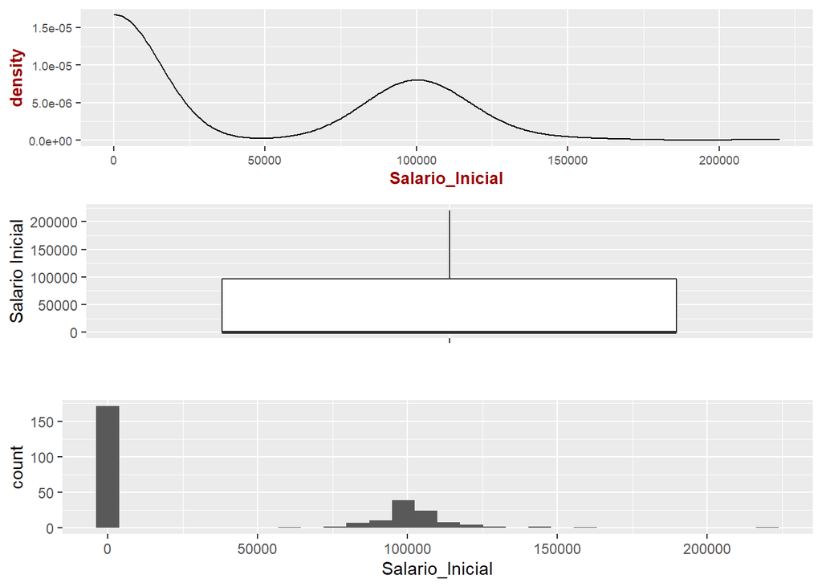

```r
attach(Base)

d1 <- ggplot(data = Base,
             aes(x =  Salario_Inicial))+
             geom_density() +
             labs(list(x = "Salario Inicial", y = "Densidad"))+
             theme(axis.title = element_text(face = "bold",
                                             colour = "#990000",
                   size = 10), axis.text = element_text(size = 7),
                   plot.title = element_text(size = rel(1.2), colour = "blue"))

bp1 <- ggplot(data = Base,aes(x = factor(""), y = Salario_Inicial)) +     geom_boxplot() +
       ylab("Salario Inicial") + xlab("")

h1 <-ggplot(data = Base,aes(x = Salario_Inicial)) +
     geom_histogram() +
     labs(list(x = "Salario Inicial", y = "Frecuencia"))

grid.arrange(d1,bp1,h1)
```

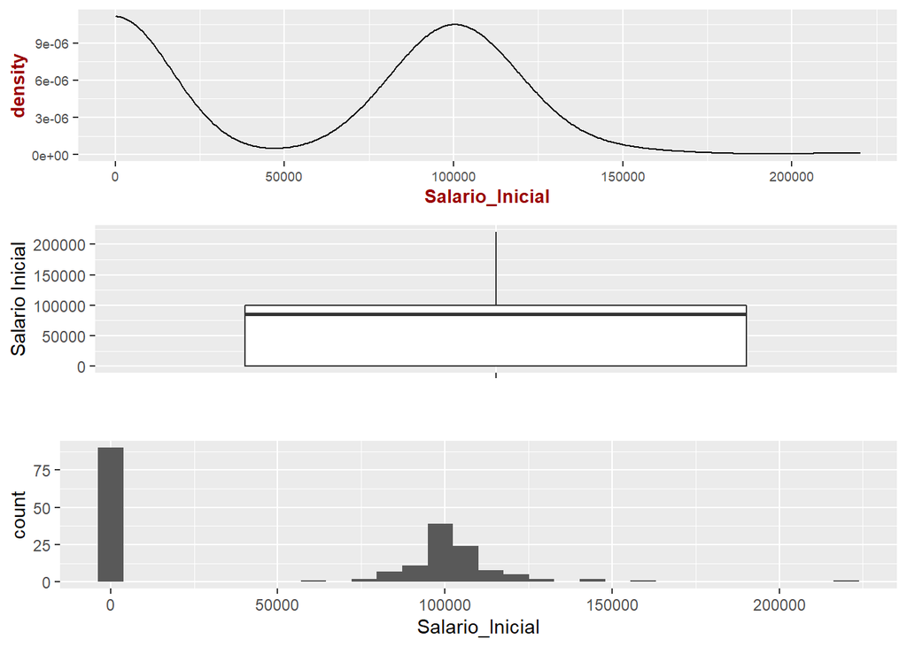

```r
# Si filtramos a los graduados que no contestaron y a los que no pusieron su salario

BaseF<-Base%>%
       filter(Salario_Inicial!=998 & Salario_Inicial!=999)
attach(BaseF)

d1 <- ggplot(data = BaseF,
             aes(x =  Salario_Inicial))+
             geom_density() +
             labs(list(x = "Salario Inicial", y = "Densidad"))+
             theme(axis.title = element_text(face = "bold", colour = "#990000",
                   size = 10), axis.text = element_text(size = 7),
                   plot.title = element_text(size = rel(1.2), colour = "blue"))

bp1 <- ggplot(data = BaseF,aes(x = factor(""), y = Salario_Inicial)) +
       geom_boxplot() +
       ylab("Salario Inicial") + xlab("")

h1 <-ggplot(data = BaseF,aes(x = Salario_Inicial)) +
     geom_histogram() +
     labs(list(x = "Salario Inicial", y = "Frecuencia"))

grid.arrange(d1,bp1,h1)
```

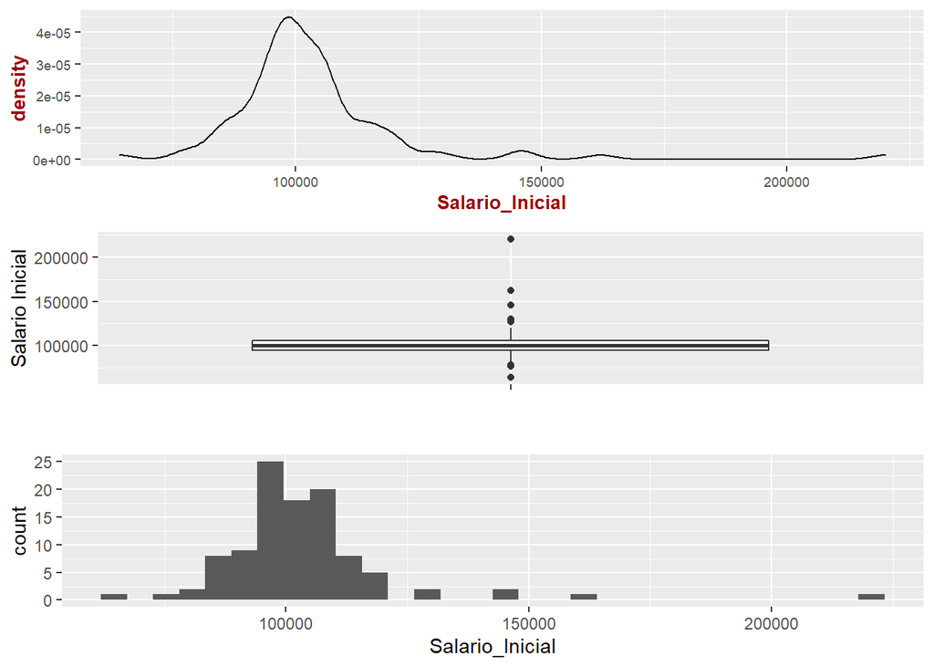

```r
# Si filtramos a los graduados que no contestaron, no pusieron su salario y a los que no tienen salario inicial

BaseF1<-Base%>%
       filter(Salario_Inicial!=0 & Salario_Inicial!=998 & Salario_Inicial!=999)
attach(BaseF1)

d1 <- ggplot(data = BaseF1,
             aes(x =  Salario_Inicial))+
             geom_density() +
             labs(list(x = "Salario Inicial", y = "Densidad"))+
             theme(axis.title = element_text(face = "bold", colour = "#990000",
                   size = 10), axis.text = element_text(size = 7),
                   plot.title = element_text(size = rel(1.2), colour = "blue"))
bp1 <- ggplot(data = BaseF1,aes(x = factor(""), y = Salario_Inicial)) +
       geom_boxplot() +
       ylab("Salario Inicial") + xlab("")

h1 <-ggplot(data = BaseF1,aes(x = Salario_Inicial)) +
     geom_histogram() +
     labs(list(x = "Salario Inicial", y = "Frecuencia"))

grid.arrange(d1,bp1,h1)
```

2. ¿Existe alguna variable (por ejemplo, edad, sexo, cuartil, idioma hablado, experiencia laboral) que afecte cuánto puede esperar ganar un estudiante?
- Empezamos analizando los cuartiles: Variable QRanking
  - Gráfico de densidad

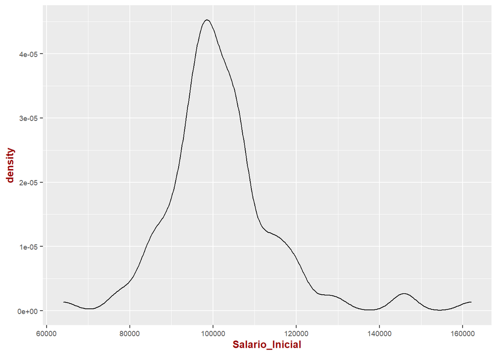

```
*   Gráfico de densidad por Ranking
```

```r
BaseF2<-BaseF1 %>%
        filter(Salario_Inicial!=220000)

attach(BaseF2)

ggplot(data = BaseF2,
             aes(x =  Salario_Inicial))+
             geom_density() +
             labs(list(x = "Salario Inicial", y = "Densidad"))+
             theme(axis.title = element_text(face = "bold", colour = "#990000",
                   size = 10), axis.text = element_text(size = 7),
                   plot.title = element_text(size = rel(1.2), colour = "blue"))
```

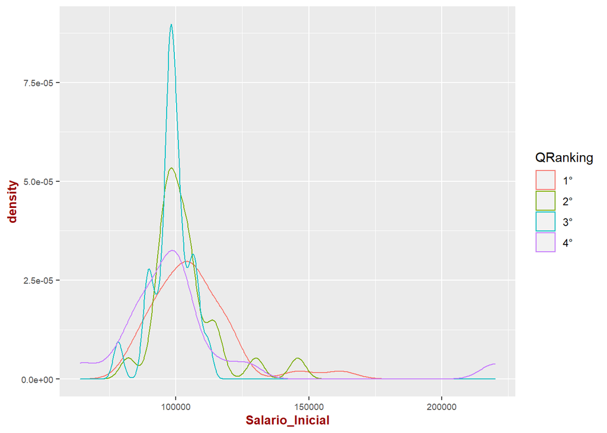

```
  *   Diagrama de cajas por Ranking
```

```r
attach(BaseF1)
ggplot(data = BaseF1,
             aes(x =  Salario_Inicial,color=QRanking))+
             geom_density() +
             labs(list(x = "Salario Inicial", y = "Densidad", color = "QRanking"))+
             theme(axis.title = element_text(face = "bold", colour = "#990000",
                   size = 10), axis.text = element_text(size = 7),
                   plot.title = element_text(size = rel(1.2), colour = "blue"))
```

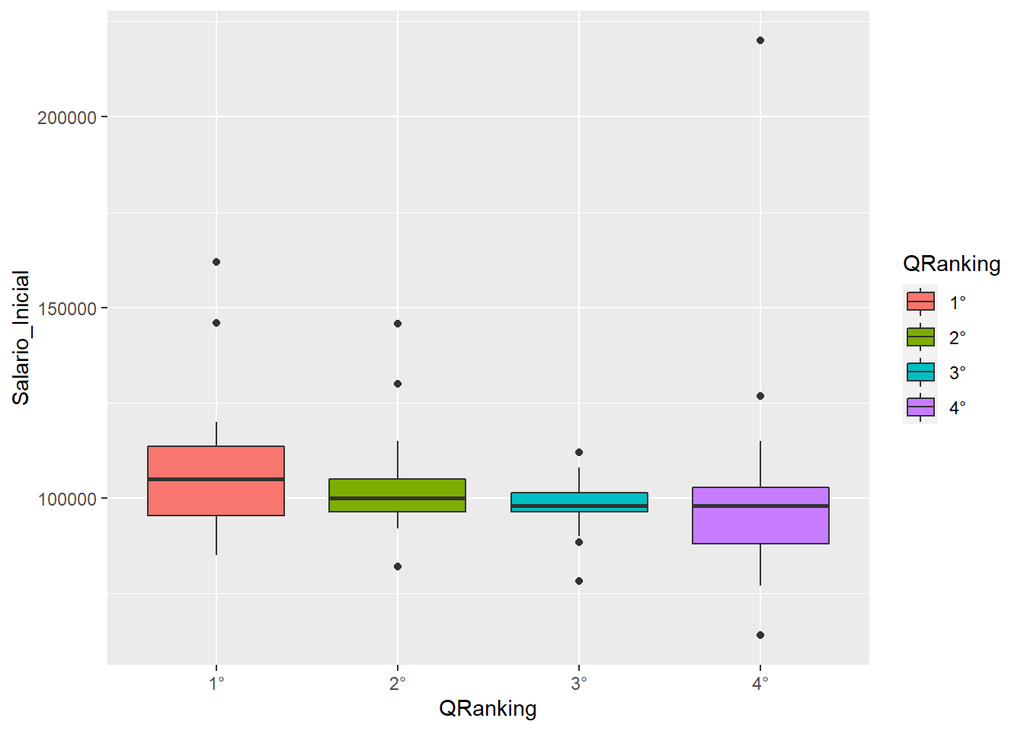

```
  *   Diagrama de barras por Ranking
```

```r
attach(BaseF1)
ggplot(data = BaseF1, aes(x = QRanking, y = Salario_Inicial))+        geom_boxplot(aes(fill = QRanking)) +
labs(list(x = "QRanking", y = "Salario Inicial"))
```

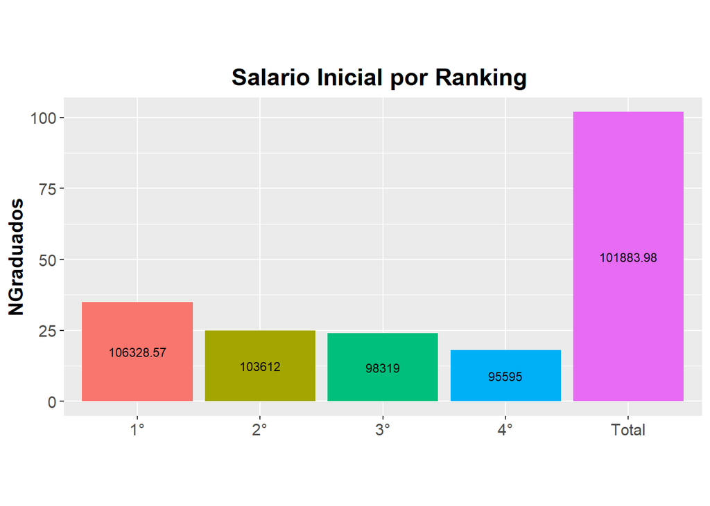

```
*   Diagrama circulares por género
```

```r
Tabla<-BaseF2 %>%
  select(QRanking,Salario_Inicial) %>%
  group_by(QRanking) %>%
  summarise(NGraduados=n(),
            Promedio=mean(Salario_Inicial,na.rm = TRUE),.groups="drop")

Resumen<-BaseF2 %>%
  select(Salario_Inicial ) %>%
  summarise(NGraduados=n(),
            Promedio=mean(Salario_Inicial,na.rm = T))

Resumen1<-cbind(QRanking="Total",Resumen)

Tabla<-rbind(Tabla,Resumen1)

Tabla$Promedio<-round(Tabla$Promedio,2)

ggplot(as.data.frame(Tabla),aes(QRanking,NGraduados , fill=QRanking)) +
  geom_bar(stat= "identity",show.legend = FALSE) +
  geom_text(aes(label=Promedio), position = position_stack(vjust = 0.5),size = 3)+
  theme (text = element_text(size=14)) +
  ggtitle ("Salario Inicial por Ranking ") +
  theme(plot.title = element_text(hjust = 0.5,face="bold"))+ # centra el título y en negrita
  theme (axis.title = element_text(face="bold", colour="black", size=rel(1.0))) + # formato a los ejes
  labs(x = NULL)+theme(aspect.ratio =0.5) #Tamaño de las barras
```

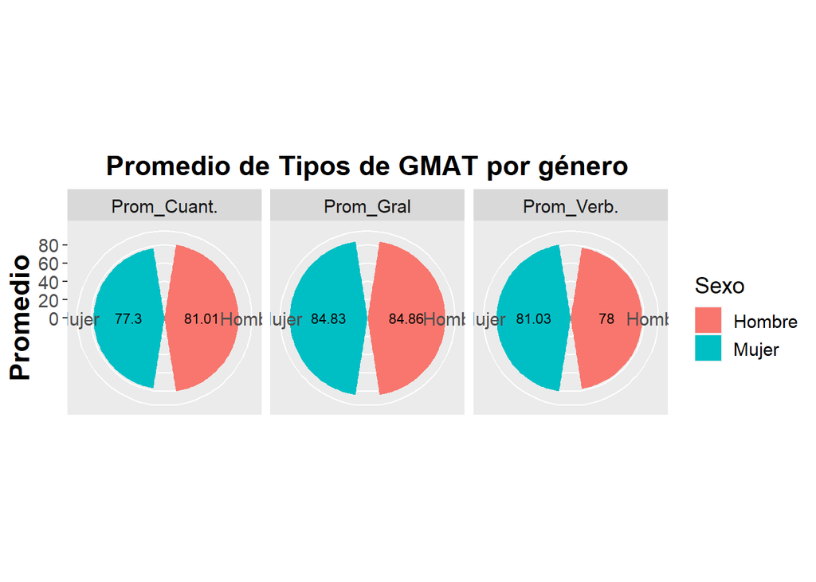

```r
Tabla<-BaseF2 %>%
  select(Sexo,Perc_Cuant_GMAT,Perc_Verbal_GMAT,Perc_Gral_GMAT) %>%
  group_by(Sexo) %>%
  summarise(Prom_Cuant.=mean(Perc_Cuant_GMAT),
            Prom_Verb.=mean(Perc_Verbal_GMAT),
            Prom_Gral=mean(Perc_Gral_GMAT),
            .groups="drop")

Tabla1<-gather(Tabla,Tipo_GMAT,Promedio,Prom_Cuant.:Prom_Gral)
Tabla1$Promedio<-round(Tabla1$Promedio,2)
# Individuales
fig1<-ggplot(as.data.frame(Tabla1),aes(Sexo, Promedio , fill= Sexo)) +
  geom_bar(stat= "identity",position = "dodge") +
  facet_grid(.~Tipo_GMAT)+
  geom_text(aes(label=Promedio), position = position_stack(vjust = 0.5),size = 3)+
  theme (text = element_text(size=14)) +
  ggtitle ("Promedio de Tipos de GMAT por género") +
  theme(plot.title = element_text(hjust = 0.5,face="bold"))+ # centra el título y en negrita
  theme (axis.title = element_text(face="bold", colour="black", size=rel(1.2)))+  # formato a los ejes
  labs(x = NULL)
fig1 + coord_polar()
```

** Preguntas:

- ¿Existe diferencia significativa en cuánto puede esperar ganar un estudiante, por el género?
- ¿Existe diferencia significativa en cuánto puede esperar ganar un estudiante, por la edad?
- ¿Existe diferencia significativa en cuánto puede esperar ganar un estudiante, por la experiencia laboral?
- ¿Existe diferencia significativa en cuánto puede esperar ganar un estudiante, por la lengua materna?

Nota: Si compara solo dos grupos y los datos no siguen una distribución normal utilizar la Prueba U de Mann-Whitney